# Guía 10 Análisis de varianza y posteriores

Diplomado en análisis de datos con R para la acuicultura.

Dr. José A. Gallardo y Dra. María Angélica Rueda.

Pontificia Universidad Católica de Valparaíso  
jose.gallardo@pucv.cl

22 October 2021

#### **Introducción**

**Análisis de Varianza**

Es una herramienta de inferencia estadística muy usada en el campo de investigación científico-técnica de las ciencias biológicas y en particular en la acuicultura. El ANOVA es un método estadístico cuya finalidad es probar hipótesis referidas a los parámetros de posición de dos o más poblaciones en estudio.

**Comparación a posteriori**

Existen diversas pruebas a posteriori para analizar el porque se rechaza la hipotesis nula que se está considerando en nuestro estudio; es decir, si rechazamos la hipótesis nula del ANOVA, la pregunta que podríamos hacernos es la siguiente **¿cuál o cuáles de las medias poblacionales en estudio son las diferentes?** Existen diversas pruebas a posteriori para analizar está problemática; no obstante, en esta guía usaremos la *prueba de Tukey*.

#### **Objetivos de aprendizaje**

Los objetivos de aprendizaje de esta guía son:

**1**. - Elaborar hipótesis estadísticas.

**2**. - Realizar análisis de varianza y comparaciones a posteriori.

**3**. - Elaborar un reporte dinámico en formato pdf con **[Rmarkdown](https://rmarkdown.rstudio.com/)**.

#### **Comandos**

A continuación, se presentan algunos comandos que deberá usar para resolver los ejercicios de esta guía.

**1.-** **lm():** se utiliza para ajustar modelos lineales. También, se puede utilizar para realizar regresiones, análisis de varianza de un factor o dos factores de clasificación (se puede considerar interacción entre los factores) y análisis de covarianza (aunque aov puede proporcionar una interfaz más conveniente para el ANOVA).

**2.-** **aov():** se usa para ajustar un modelo de análisis de varianza.

**3.-** **anova():** se usa para hacer un ANOVA sobre el objeto obtenido al ajustar un modelo con las funciones lm() o aov().

**4.-** **TukeyHSD():** se usa para hacer la prueba a posteriori de Tukey.

**Nota:** La prueba Tukey trabaja sobre un objeto *aov*, no sobre un objeto lm.

### **Ejercicio 1.** **Elaborar archivo Rmarkdown**

Usando lo aprendido en la unidad 1 del curso elabore y configure un archivo o file con extensión **.Rmd** y configúrelo para exportar el resultado como un documento dinámico **pdf**.

Utilice el siguiente ejemplo para completar la información de metadatos: Título: Reporte Anova y posteriores, nombre del autor: Su nombre.

Luego guarde inmediatamente su *script* como **script_7_nombre_apellido.Rmd**. Al finalizar la actividad deberá exportar y almacenar este script en su carpeta drive de tareas.

### **Ejercicio 2.** **Configuración del reporte**

En el primer bloque de códigos o **chunk** configure los comandos de la siguiente manera *knitr::opts_chunk$set(echo = TRUE)* y cargue las librerías **stats**, **graphics**, **ggplot2**, **readxl**, **pander**, **dplyr** y **knitr**.

```r
knitr::opts_chunk$set(echo = TRUE)

# Librería stats está instalada por defecto en la base de R
library(stats)

# Librería graphics está instalada por defecto en la base de R
library(graphics)

# Librería para gráficas avanzadas
library(ggplot2)

# Librería para importar datos
library(readxl)

# Librería para mostrar en formato tabla los resultados de un objeto
library(pander)

# Librería para usar funciones de tidyverse
library(dplyr)

# Librería para hacer tablas
library(knitr)
```

### **Ejercicio 3.** **Anova a un criterio de clasificación con dos niveles**

La base de datos **Tilapia_nilotica_data.xlsx** contiene información del peso final **(Final_Weight_g)** y cepa **(Cepa)** de 200 tilapias. Los investigadores desean evaluar si el crecimiento medido como peso final es diferente entre dos Cepas comerciales de *Oreochromis niloticus* (**Spring** *vs* **cepa B**). Ambas cepas se evaluaron durante 157 días (34 días en vivero y 123 en engorde) en la finca Los Pozos, El Rosario, Sinaloa, México. La cantidad de observaciones del set de datos **Tilapia_nilotica_data.xlsx** es igual a 200, 100 observaciones para cada cepa. Datos simulados a partir de información estadística del siguiente artículo [Espinosa-Chaurand et al., 2019](https://scielo.conicyt.cl/scielo.php?pid=S0718-560X2019000300440&script=sci_arttext)

**a).** Formule la hipótesis nula y alternativa para este experimento.

```r
#**H~0~**: $$ \mu_{Spring} = \mu_{B}$$

#**H~1~**: $$ \mu_{Spring} \ne \mu_{B}$$
```

**b).** Importe el set de datos **Tilapia_nilotica_data.xlsx** usando la función **read_excel()** de la librería **readxl**, llame al objeto Tilapia_nilotica. Transformar en factor la variable Cepa con la función **as.factor()**. Explore el set de datos usando las funciones **head()**, **str()** y **summary()**.

```r
Tilapia_nilotica <- read_excel("Tilapia_nilotica_data.xlsx")
Tilapia_nilotica$Cepa <- as.factor(Tilapia_nilotica$Cepa)
head(Tilapia_nilotica)
```

```
## # A tibble: 6 × 3
##      ID Cepa   Final_Weight_g
##   <dbl> <fct>           <dbl>
## 1     1 Spring            495
## 2     2 Spring            538
## 3     3 Spring            484
## 4     4 Spring            613
## 5     5 Spring            546
## 6     6 Spring            485
```

```r
str(Tilapia_nilotica)
```

```
## tibble [200 × 3] (S3: tbl_df/tbl/data.frame)
##  $ ID            : num [1:200] 1 2 3 4 5 6 7 8 9 10 ...
##  $ Cepa          : Factor w/ 2 levels "B","Spring": 2 2 2 2 2 2 2 2 2 2 ...
##  $ Final_Weight_g: num [1:200] 495 538 484 613 546 485 554 568 559 512 ...
```

```r
summary(Tilapia_nilotica)
```

```
##        ID             Cepa     Final_Weight_g
##  Min.   :  1.00   B     :100   Min.   :207.0
##  1st Qu.: 50.75   Spring:100   1st Qu.:384.0
##  Median :100.50                Median :494.0
##  Mean   :100.50                Mean   :466.4
##  3rd Qu.:150.25                3rd Qu.:548.2
##  Max.   :200.00                Max.   :656.0
```

**c).** Realice un análisis exploratorio de datos de la variable bajo estudio. A partir del set de datos de elabore un gráfico de cajas y bigotes para la variable **Final_Weight_g**.

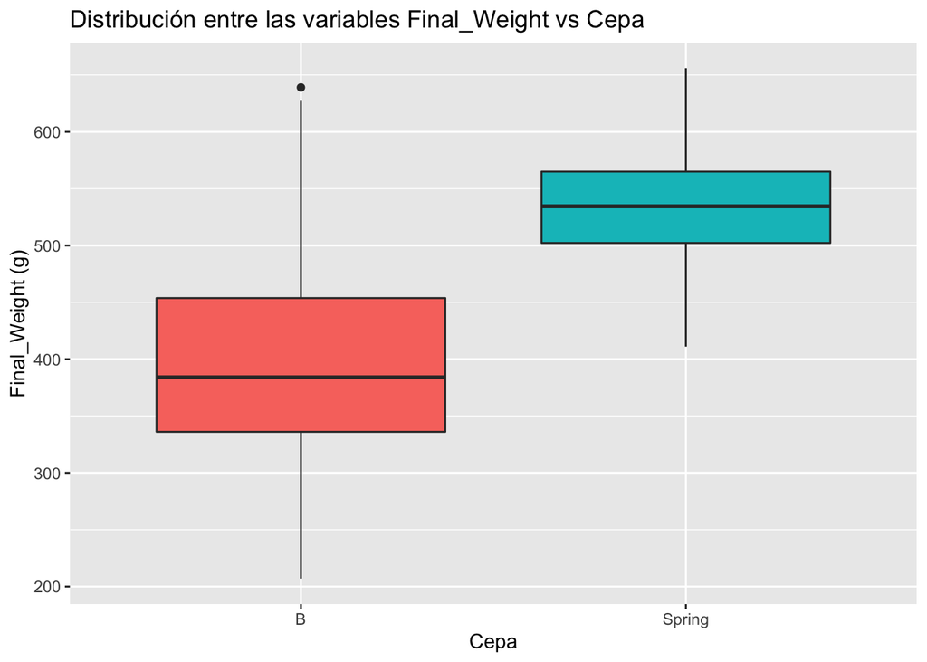

```r
Tilapia_nilotica %>%
          ggplot(aes(x= Cepa,y=Final_Weight_g,fill=Cepa))+
                geom_boxplot()+
                theme(legend.position="none")+
                labs(x="Cepa",y="Final_Weight (g)",title="Distribución entre las variables Final_Weight vs Cepa")
```

**d).** Incluya una tabla con los estimadores puntuales de los promedios y las varianzas de la variable Final_Weight_g para cada nivel del factor Cepa.

```r
# Promedio y varianza de la variable Final_Weight_g para la Cepa Spring.

M_V_Final_Weight_g_Spring <- Tilapia_nilotica %>%
                             filter(Cepa == "Spring") %>%
summarize(media_Final_Weight_g_Spring= mean(Final_Weight_g),
          varianza_Final_Weight_g_Spring= var(Final_Weight_g))

M_V_Final_Weight_g_Spring
```

```
## # A tibble: 1 × 2
##   media_Final_Weight_g_Spring varianza_Final_Weight_g_Spring
##                         <dbl>                          <dbl>
## 1                        534.                          2274.
```

```r
# Promedio y varianza de la variable Final_Weight_g para la Cepa B.
M_V_Final_Weight_g_B <- Tilapia_nilotica %>%
                        filter(Cepa == "B") %>%
summarize(media_Final_Weight_g_B= mean(Final_Weight_g),
          varianza_Final_Weight_g_B= var(Final_Weight_g))

M_V_Final_Weight_g_B
```

```
## # A tibble: 1 × 2
##   media_Final_Weight_g_B varianza_Final_Weight_g_B
##                    <dbl>                     <dbl>
## 1                   399.                     9616.
```

```r
Tabla <- data.frame(M_V_Final_Weight_g_Spring, M_V_Final_Weight_g_B)
colnames(Tabla) <- c("Peso_Final_Promedio_Cepa_Spring","Varianza_Peso_Final_Spring", "Peso_Final_Promedio_Cepa_B","Varianza_Peso_Final_B")

knitr::kable(Tabla,caption ="Medias y varianzas de la variable Final_Weight(g) para las cepas Spring y B")
```

Medias y varianzas de la variable Final_Weight(g) para las cepas Spring y B

| Peso_Final_Promedio_Cepa_Spring | Varianza_Peso_Final_Spring | Peso_Final_Promedio_Cepa_B | Varianza_Peso_Final_B |
| --- | --- | --- | --- |
| 534.26 | 2274.194 | 398.6 | 9616.444 |

**e).** Realice el ajuste del siguiente modelo usando la función aov(), donde los parámetros son los siguientes: variable respuesta **Final_Weight_g** y como factor de clasificación **Cepa**, como set de datos (data=Tilapia_nilotica). Llame al objeto model1_anova1. Utilice el simbolo ~ para relacionar la variable respuesta con el factor de clasificación. Luego, realice el anova() del objeto model1_anova1. Use la función pander::pander() para mostrar los resultados del modelo (model1_anova1), coloque en el parámetro caption “ANOVA a una vía de clasificación usando la función aov().”

```r
model1_anova1 <- aov(Final_Weight_g ~ Cepa, data=Tilapia_nilotica)
anova(model1_anova1)
```

```
## Analysis of Variance Table
##
## Response: Final_Weight_g
##            Df  Sum Sq Mean Sq F value    Pr(>F)
## Cepa        1  920182  920182  154.77 < 2.2e-16 ***
## Residuals 198 1177173    5945
## ---
## Signif. codes:  0 '***' 0.001 '**' 0.01 '*' 0.05 '.' 0.1 ' ' 1
```

```r
pander::pander(model1_anova1, caption = "ANOVA a una vía de clasificación usando la función aov().")
```

ANOVA a una vía de clasificación usando la función aov().

|  | Df | Sum Sq | Mean Sq | F value | Pr(>F) |
| --- | --- | --- | --- | --- | --- |
| **Cepa** | 1 | 920182 | 920182 | 154.8 | 1.25e-26 |
| **Residuals** | 198 | 1177173 | 5945 | NA | NA |

**f).** Interprete los resultados.

```r
#El efecto cepa es estadísticamente significativo (p valor menor al nivel de significación del 5%). En consecuencia se rechaza la hipótesis nula. Por lo tanto, existen diferencias entre los pesos finales promedios de las cepa Spring y B.
```

### **Ejercicio 4.** **Anova a un criterio de clasificación con tres niveles y Prueba a Posteriori Tukey**

En este estudio de caso trabajaremos con un set de datos de trucha arcoíris en una estación de cultivo del Ecuador (n=54).

Las variables de estudio se describen a continuación:

| **variable** | **Descripción** | **Tipo de efecto/variable** |
| --- | --- | --- |
| **Probiotico** | Dosis de probiótico fresh plus: 0 g/kg (P0: alimento sin probiotico) , 6 g/kg (P1= 6 gramos de probiotico por kilo de alimento) y 12 g/Kg (P2: 12 gramos de probiotico por kilo de alimento ). | Criterio de clasificación. |
| **Fuente** | Dos fuentes de agua: F1: Agua Natural del río Papallacta - normalmente usada en la crianza de los peces y F2: mezcla de agua natural con agua geotermal | Criterio de clasificación. |
| **Tiempo_Dias** | Cantidad de días en los que se llevó a cabo el experimento | Criterio de clasificación. |
| **indice_condicion_corporal** | Índice de condición corporal. | Continua |

**a).** Formule una hipótesis para evaluar si el índice de condición difiere entre días de cultivo.

```r
#**H~0~**: $$ \mu_{15} = \mu_{30} = \mu_{45}$$

#**H~1~**: Al menos una de las medias del indice corporal es diferente entre los días evaluados.
```

**b).** Importe el set de datos **Trucha.xlsx** usando la función **read_excel()** de la librería **readxl**, llame al objeto Trucha. Transformar en factor las variables Probiotico, Fuente y Tiempo_Dias con la función **as.factor()**. Explore el set de datos usando las funciones **head()**, **str()** y **summary()**.

```r
Trucha <- read_excel("Trucha.xlsx")
Trucha$Probiotico <- as.factor(Trucha$Probiotico)
Trucha$Fuente <- as.factor(Trucha$Fuente)
Trucha$Tiempo_Dias <- as.factor(Trucha$Tiempo_Dias)
head(Trucha)
```

```
## # A tibble: 6 × 4
##   Probiotico Fuente Tiempo_Dias indice_condicion_corporal
##   <fct>      <fct>  <fct>                           <dbl>
## 1 P1         F1     15                               1.07
## 2 P1         F1     15                               1.02
## 3 P1         F1     15                               1.31
## 4 P2         F1     15                               1.17
## 5 P2         F1     15                               1.19
## 6 P2         F1     15                               1.36
```

```r
str(Trucha)
```

```
## tibble [54 × 4] (S3: tbl_df/tbl/data.frame)
##  $ Probiotico               : Factor w/ 3 levels "P0","P1","P2": 2 2 2 3 3 3 1 1 1 2 ...
##  $ Fuente                   : Factor w/ 2 levels "F1","F2": 1 1 1 1 1 1 1 1 1 2 ...
##  $ Tiempo_Dias              : Factor w/ 3 levels "15","30","45": 1 1 1 1 1 1 1 1 1 1 ...
##  $ indice_condicion_corporal: num [1:54] 1.07 1.02 1.31 1.17 1.19 ...
```

```r
summary(Trucha)
```

```
##  Probiotico Fuente  Tiempo_Dias indice_condicion_corporal
##  P0:18      F1:27   15:18       Min.   :0.9575
##  P1:18      F2:27   30:18       1st Qu.:1.0470
##  P2:18              45:18       Median :1.1541
##                                 Mean   :1.1572
##                                 3rd Qu.:1.2628
##                                 Max.   :1.4649
```

**c).** Realice un análisis exploratorio de datos de la variable bajo estudio. A partir del set de datos de elabore un gráfico de cajas y bigotes para la variable indice_condicion_corporal.

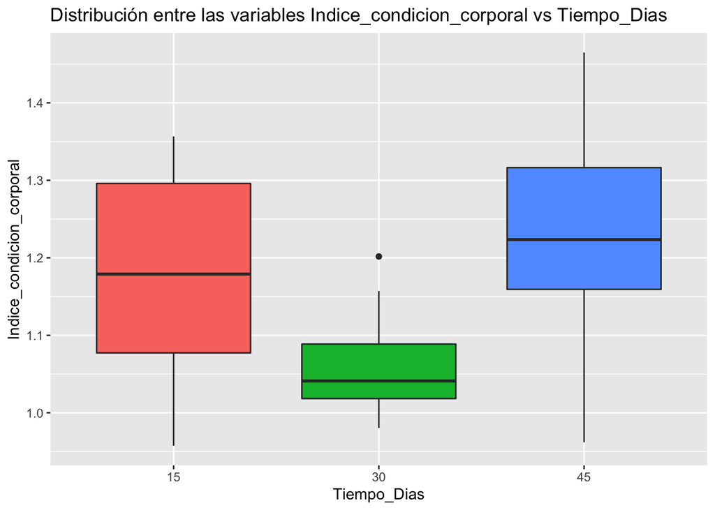

```r
Trucha %>%
          ggplot(aes(x=Tiempo_Dias,y=indice_condicion_corporal,fill=Tiempo_Dias))+
                geom_boxplot()+
                theme(legend.position="none")+
                labs(x="Tiempo_Dias",y="Indice_condicion_corporal",title="Distribución entre las variables Indice_condicion_corporal vs Tiempo_Dias")
```

**d).** Calcule los estimadores puntuales de los promedios y las varianzas de la variable indice_condicion_corporal para cada nivel del factor Tiempo_Dias.

```r
M_V_ICC_15 <- Trucha %>%
              filter(Tiempo_Dias == "15") %>%
summarize(media_ICC_15= mean(indice_condicion_corporal),
          varianza_ICC_15= var(indice_condicion_corporal))

M_V_ICC_15
```

```
## # A tibble: 1 × 2
##   media_ICC_15 varianza_ICC_15
##          <dbl>           <dbl>
## 1         1.18          0.0170
```

```r
M_V_ICC_30 <- Trucha %>%
              filter(Tiempo_Dias == "30") %>%
summarize(media_ICC_30= mean(indice_condicion_corporal),
          varianza_ICC_30= var(indice_condicion_corporal))

M_V_ICC_30
```

```
## # A tibble: 1 × 2
##   media_ICC_30 varianza_ICC_30
##          <dbl>           <dbl>
## 1         1.06         0.00358
```

```r
M_V_ICC_45 <- Trucha %>%
              filter(Tiempo_Dias == "45") %>%
summarize(media_ICC_45= mean(indice_condicion_corporal),
          varianza_ICC_45= var(indice_condicion_corporal))

M_V_ICC_45
```

```
## # A tibble: 1 × 2
##   media_ICC_45 varianza_ICC_45
##          <dbl>           <dbl>
## 1         1.23          0.0126
```

**e).** Realice el ajuste del siguiente modelo usando la función aov(), donde los parámetros son los siguientes: variable respuesta indice_condicion_corporal y como factor de clasificación Tiempo_Dias, como set de datos (data=Trucha). Llame al objeto model2_anova1. Utilice el simbolo ~ para relacionar la variable respuesta con el factor de clasificación. Realice el anova() del objeto model2_anova1. Use la función pander::pander() para mostrar los resultados del modelo (model2_anova1), coloque en el parámetro caption un título a la tabla.

```r
model2_anova1 <- aov(indice_condicion_corporal ~ Tiempo_Dias, data=Trucha)
anova(model2_anova1)
```

```
## Analysis of Variance Table
##
## Response: indice_condicion_corporal
##             Df  Sum Sq  Mean Sq F value    Pr(>F)
## Tiempo_Dias  2 0.27968 0.139842  12.634 3.493e-05 ***
## Residuals   51 0.56449 0.011068
## ---
## Signif. codes:  0 '***' 0.001 '**' 0.01 '*' 0.05 '.' 0.1 ' ' 1
```

```r
pander::pander(model2_anova1, caption = "ANOVA a un criterio de clasificación con tres niveles usando la función aov().")
```

ANOVA a un criterio de clasificación con tres niveles usando la función aov().

|  | Df | Sum Sq | Mean Sq | F value | Pr(>F) |
| --- | --- | --- | --- | --- | --- |
| **Tiempo_Dias** | 2 | 0.2797 | 0.1398 | 12.63 | 3.493e-05 |
| **Residuals** | 51 | 0.5645 | 0.01107 | NA | NA |

**f).** hacer la prueba a posteriori de Tukey sobre el objeto model2_anova1. Para esto use la función TukeyHSD(). LLame el objeto Tuk_model2_anova1.

```r
Tuk_model2_anova1 <- TukeyHSD(model2_anova1)
Tuk_model2_anova1
```

```
##   Tukey multiple comparisons of means
##     95% family-wise confidence level
##
## Fit: aov(formula = indice_condicion_corporal ~ Tiempo_Dias, data = Trucha)
##
## $Tiempo_Dias
##              diff         lwr         upr     p adj
## 30-15 -0.11419567 -0.19885084 -0.02954049 0.0056066
## 45-15  0.05920552 -0.02544965  0.14386069 0.2194788
## 45-30  0.17340119  0.08874601  0.25805636 0.0000255
```

**g).** Interprete los resultados.

```r
#El efecto Tiempo_Dias es estadísticamente significativo (p valor menor al nivel de significación del 5%). En consecuencia se rechaza la hipótesis nula. Por lo tanto, al menos existe un indice corporal promedio diferente en los días evaluados. Para estudiar a que son debidas esas diferencias se hizo una prueba de comparaciones a posteriori de Tukey y se obtuvo que las diferencias se presentaron entre los indices de condiciones corporales promedios de los días (30 y 15) y también entre (45 y 30).
```

### **Ejercicio 5.** **Anova a dos criterios de clasificación y prueba a Posteriori Tukey**

En este estudio de caso trabajaremos con un set de datos de Camarón blanco del Pacífico (*Litopenaeus vannamei*) en una estación de cultivo de México (n=120). Datos tomados del siguiente artículo [Gonzalez-Galaviza et al.,2020](https://www.tandfonline.com/doi/full/10.1080/1828051X.2020.1733444)

Las variables de estudio se describen a continuación:

| **variable** | **Descripción** | **Tipo de efecto/variable** |
| --- | --- | --- |
| **ID_Camaron** | Identificador del camarón | Identificador. |
| **Tank** | Tanques (10 camarones por tanque) | Criterio de clasificación . |
| **Diet** | Se formularon dos dietas experimentales con diferente fuente proteica (vegetal y animal) | Criterio de clasificación. |
| **Genotype** | Dos genotipos evaluados, camarones de crecimiento rápido (FG) y alta resistencia (HR). | Criterio de clasificación. |
| **Initial_Weight** | Peso inicial en gramos. | Continua. |

**a).** Formule la hipótesis nula y alternativa para evaluar si el peso inicial es el mismo entre los camarones asignados a las diferentes dietas y estanques. Recuerde que en un experimento de este tipo, no deben haber grupos con mayor peso al inicio, pues esto invalida el resultado de crecimiento.

```r
#**H~0~**: $$\mu_{Animal_Tank1} = \mu_{Animal_Tank2} = \mu_{Animal_Tank3} = \mu_{Vegetal_Tank1} = \mu_{Vegetal_Tank2} = \mu_{Vegetal_Tank3}$$

#**H~1~**: Al menos una de las medias del peso inicial es diferente para cada dieta en cada tanque.
```

**b).** Importe el set de datos **Camarones.xlsx** usando la función **read_excel()** de la librería **readxl**, llame al objeto Camarones. Transformar en factor las variables Tank, Diet y Genotype con la función **as.factor()**. Explore el set de datos usando las funciones **head()**, **str()** y **summary()**.

```r
Camarones <- read_excel("Camarones.xlsx")
Camarones$Tank <- as.factor(Camarones$Tank)
Camarones$Diet <- as.factor(Camarones$Diet)
Camarones$Genotype <- as.factor(Camarones$Genotype)
head(Camarones)
```

```
## # A tibble: 6 × 5
##   ID_Camaron Tank  Diet   Genotype Initial_Weight
##   <chr>      <fct> <fct>  <fct>             <dbl>
## 1 1_1        1     Animal FG                 1.83
## 2 1_2        1     Animal FG                 1.74
## 3 1_3        1     Animal FG                 2.3
## 4 1_4        1     Animal FG                 2.21
## 5 1_5        1     Animal FG                 2.01
## 6 1_6        1     Animal FG                 2.04
```

```r
str(Camarones)
```

```
## tibble [120 × 5] (S3: tbl_df/tbl/data.frame)
##  $ ID_Camaron    : chr [1:120] "1_1" "1_2" "1_3" "1_4" ...
##  $ Tank          : Factor w/ 3 levels "1","2","3": 1 1 1 1 1 1 1 1 1 1 ...
##  $ Diet          : Factor w/ 2 levels "Animal","Vegetal": 1 1 1 1 1 1 1 1 1 1 ...
##  $ Genotype      : Factor w/ 2 levels "FG","HR": 1 1 1 1 1 1 1 1 1 1 ...
##  $ Initial_Weight: num [1:120] 1.83 1.74 2.3 2.21 2.01 2.04 1.6 1.72 1.75 2.2 ...
```

```r
summary(Camarones)
```

```
##   ID_Camaron        Tank        Diet    Genotype Initial_Weight
##  Length:120         1:40   Animal :60   FG:60    Min.   :1.020
##  Class :character   2:40   Vegetal:60   HR:60    1st Qu.:1.790
##  Mode  :character   3:40                         Median :2.030
##                                                  Mean   :2.051
##                                                  3rd Qu.:2.272
##                                                  Max.   :2.930
```

**c).** Realice un análisis exploratorio de datos de la variable bajo estudio. A partir del set de datos de elabore un gráfico de cajas y bigotes para la variable **Initial_Weight**, como criterios de clasificación Diet y Tank y particionado por Tank use **facet_wrap(~ Tank)**.

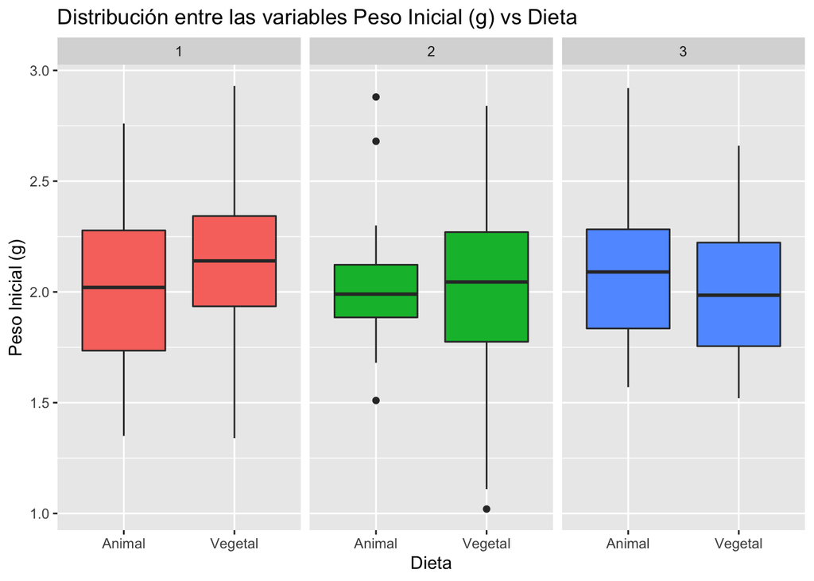

```r
Camarones %>%
                ggplot(aes(x= Diet,y=Initial_Weight,fill=Tank))+
                geom_boxplot()+
                theme(legend.position="none")+
                labs(x="Dieta",y="Peso Inicial (g)",title="Distribución entre las variables Peso Inicial (g) vs Dieta")+
                facet_wrap(~ Tank)
```

**d).** Halle los estimadores puntuales de los promedios y las varianzas de la variable Initial_Weight para cada nivel del factor Diet y para cada nivel del factor Tank.

```r
# Promedios y varianzas de la variable Initial_Weight para cada dieta "Diet" (Animal y Vegetal) y en cada Tank (1, 2 y 3)

M_V_IW_Animal_T1 <- Camarones %>%
                    filter(Diet == "Animal", Tank == "1") %>%
                  summarize(media_IW_A_T1=mean(Initial_Weight),
                          varianza_IW_A_T1= var(Initial_Weight))
M_V_IW_Animal_T1
```

```
## # A tibble: 1 × 2
##   media_IW_A_T1 varianza_IW_A_T1
##           <dbl>            <dbl>
## 1          2.02            0.156
```

```r
M_V_IW_Animal_T2 <- Camarones %>%
                    filter(Diet == "Animal", Tank == "2") %>%
                  summarize(media_IW_A_T2=mean(Initial_Weight),
                          varianza_IW_A_T2= var(Initial_Weight))
M_V_IW_Animal_T2
```

```
## # A tibble: 1 × 2
##   media_IW_A_T2 varianza_IW_A_T2
##           <dbl>            <dbl>
## 1          2.05            0.100
```

```r
M_V_IW_Animal_T3 <- Camarones %>%
                    filter(Diet == "Animal", Tank == "3") %>%
                  summarize(media_IW_A_T3=mean(Initial_Weight),
                          varianza_IW_A_T3= var(Initial_Weight))
M_V_IW_Animal_T3
```

```
## # A tibble: 1 × 2
##   media_IW_A_T3 varianza_IW_A_T3
##           <dbl>            <dbl>
## 1          2.09            0.103
```

```r
M_V_IW_Vegetal_T1 <- Camarones %>%
                    filter(Diet == "Vegetal", Tank == "1") %>%
                  summarize(media_IW_V_T1=mean(Initial_Weight),
                          varianza_IW_V_T1= var(Initial_Weight))
M_V_IW_Vegetal_T1
```

```
## # A tibble: 1 × 2
##   media_IW_V_T1 varianza_IW_V_T1
##           <dbl>            <dbl>
## 1          2.13            0.148
```

```r
M_V_IW_Vegetal_T2 <- Camarones %>%
                    filter(Diet == "Vegetal", Tank == "2") %>%
                  summarize(media_IW_V_T2=mean(Initial_Weight),
                          varianza_IW_V_T2= var(Initial_Weight))
M_V_IW_Vegetal_T2
```

```
## # A tibble: 1 × 2
##   media_IW_V_T2 varianza_IW_V_T2
##           <dbl>            <dbl>
## 1          2.02            0.216
```

```r
M_V_IW_Vegetal_T3 <- Camarones %>%
                    filter(Diet == "Vegetal", Tank == "3") %>%
                  summarize(media_IW_V_T3=mean(Initial_Weight),
                          varianza_IW_V_T3= var(Initial_Weight))
M_V_IW_Vegetal_T3
```

```
## # A tibble: 1 × 2
##   media_IW_V_T3 varianza_IW_V_T3
##           <dbl>            <dbl>
## 1          2.01           0.0886
```

**e).** Realice el ajuste del siguiente modelo usando la función aov(), donde los parámetros son los siguientes: variable respuesta **Initial_Weight** y como factores de clasificación Diet y Tank, como set de datos (data=Camarones). Llame al objeto model3_anova1. Utlice el simbolo ~ para relacionar la variable respuesta con los factores de clasificación y su interacción. Realice el anova() del objeto model3_anova1. Use la función pander::pander() para mostrar los resultados del modelo (model3_anova1), coloque en el parámetro caption un título a la tabla.

```r
model3_anova1 <- aov(Initial_Weight ~ Diet + Tank + Diet*Tank, data=Camarones)
anova(model3_anova1)
```

```
## Analysis of Variance Table
##
## Response: Initial_Weight
##            Df  Sum Sq  Mean Sq F value Pr(>F)
## Diet        1  0.0000 0.000013  0.0001 0.9921
## Tank        2  0.0406 0.020282  0.1499 0.8610
## Diet:Tank   2  0.1891 0.094556  0.6989 0.4993
## Residuals 114 15.4234 0.135293
```

```r
pander::pander(model3_anova1, caption = "ANOVA a dos vías de clasificación usando la función aov().")
```

ANOVA a dos vías de clasificación usando la función aov().

|  | Df | Sum Sq | Mean Sq | F value | Pr(>F) |
| --- | --- | --- | --- | --- | --- |
| **Diet** | 1 | 1.333e-05 | 1.333e-05 | 9.855e-05 | 0.9921 |
| **Tank** | 2 | 0.04056 | 0.02028 | 0.1499 | 0.861 |
| **Diet:Tank** | 2 | 0.1891 | 0.09456 | 0.6989 | 0.4993 |
| **Residuals** | 114 | 15.42 | 0.1353 | NA | NA |

**f).** Interprete los resultados.

```r
#Los efectos Diet, Tank y la interacción Diet-Tank no son estadísticamente significativos (p valor mayor al nivel de significación del 5%). En consecuencia no hay evidencia para rechazar la hipótesis nula. Por lo tanto, no existen diferencias entre las pesos iniciales promedio para las dietas Animal y Vegetal en los 3 Tanques.
```